# Richness in PPA

This document describes PPA, using **Richness** as the focal biodiversity metric.

Important terms:

- `Stage`: metacommunity represents *with* seed rain, isolation represents *without* seed rain
- `Ninitial`: Planted species richness

# 1 Initial inspection

The raw data:

```r
PPA$data %>%
    as.data.frame() %>%
    head(10) %>%
    kable()
```

| Ninitial | Rep | SeedRain | Stage | Year | FDis | total.biomass | Shannon | Richness |
| --- | --- | --- | --- | --- | --- | --- | --- | --- |
| 1 | 1 | 100 | metacommunity | 100 | 0.0000000 | 30.83201 | 1.000000 | 1 |
| 1 | 1 | 100 | isolation | 200 | 0.0000000 | 30.13875 | 1.000000 | 1 |
| 2 | 1 | 100 | metacommunity | 100 | 0.9848768 | 14.69283 | 1.685566 | 2 |
| 2 | 1 | 100 | isolation | 200 | 0.0000000 | 13.01202 | 1.000000 | 1 |
| 4 | 1 | 100 | metacommunity | 100 | 0.0000000 | 59.50072 | 1.000000 | 1 |
| 4 | 1 | 100 | isolation | 200 | 0.0000000 | 58.04613 | 1.000000 | 1 |
| 8 | 1 | 100 | metacommunity | 100 | 0.3090527 | 81.09189 | 1.872723 | 6 |
| 8 | 1 | 100 | isolation | 200 | 0.9475482 | 74.68211 | 1.666687 | 2 |
| 16 | 1 | 100 | metacommunity | 100 | 0.7233933 | 70.61579 | 1.994583 | 9 |
| 16 | 1 | 100 | isolation | 200 | 0.6630782 | 72.36606 | 1.526867 | 3 |

Plotted without fits:

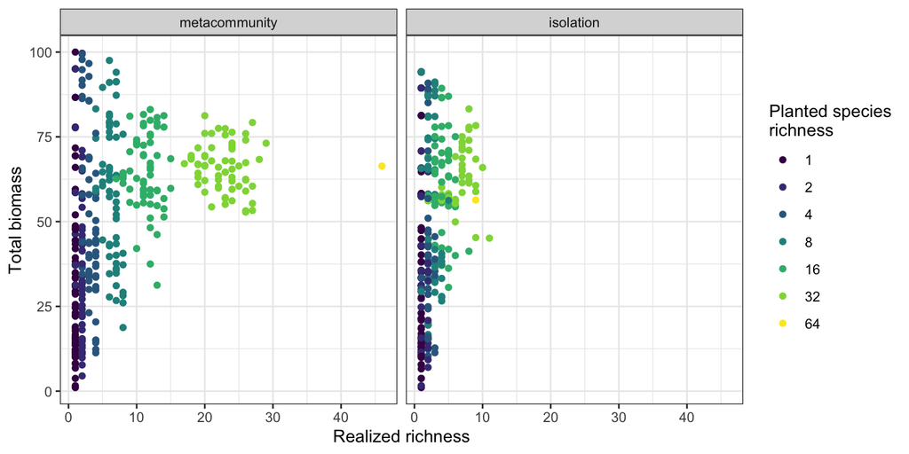

```r
ggplot(PPA %>% unnest(data)) +
    geom_point(aes(x = Richness,
                   y = total.biomass,
                   color = as.factor(Ninitial))) +
    facet_grid(. ~ Stage) +
    labs(x = "Realized richness",
         y = "Total biomass",
         color = "Planted species\nrichness") +
    scale_color_viridis(discrete = TRUE) +
    theme_bw()
```

# 2 Fitting the model

## 2.1 Main effect

The main effect represents the relationship between diversity and total biomass without taking into account the richness treatment.

To produce this model, we use the call:

```r
brm(formula = total.biomass ~ -1 + Stage + Stage:Richness,
    data = PPA)
```

A summary table of the result:

```r
PPA$mainEffect[[1]]
```

```
##  Family: gaussian
##   Links: mu = identity; sigma = identity
## Formula: total.biomass ~ -1 + Stage + Stage:Richness
##    Data: d_ (Number of observations: 770)
## Samples: 4 chains, each with iter = 2000; warmup = 1000; thin = 1;
##          total post-warmup samples = 4000
##
## Population-Level Effects:
##                             Estimate Est.Error l-95% CI u-95% CI Rhat Bulk_ESS Tail_ESS
## Stagemetacommunity             42.27      1.50    39.27    45.18 1.00     2532     2553
## Stageisolation                 38.54      1.80    34.92    41.98 1.00     2524     2688
## Stagemetacommunity:Richness     1.21      0.14     0.95     1.49 1.00     2585     2375
## Stageisolation:Richness         3.74      0.52     2.72     4.76 1.00     2435     2389
##
## Family Specific Parameters:
##       Estimate Est.Error l-95% CI u-95% CI Rhat Bulk_ESS Tail_ESS
## sigma    21.29      0.55    20.25    22.40 1.00     3784     2629
##
## Samples were drawn using sampling(NUTS). For each parameter, Bulk_ESS
## and Tail_ESS are effective sample size measures, and Rhat is the potential
## scale reduction factor on split chains (at convergence, Rhat = 1).
```

> Note the `Rhat` summary column: variation from 1.0 indicates the the model did not converge.

The R-squared:

```r
rstantools::bayes_R2(PPA$mainEffect[[1]])
```

```
##    Estimate  Est.Error      Q2.5     Q97.5
## R2 0.150124 0.02184435 0.1094943 0.1943493
```

### 2.1.1 Posterior predictive checks

We next use posterior predictive checks (PPC) to judge the fit of the model. These compare the real data to the posterior distribution, conditioned on the observed data.

The density of both the real data (`y`, black line), and from fitted draws of the models (`y_rep`, blue lines).

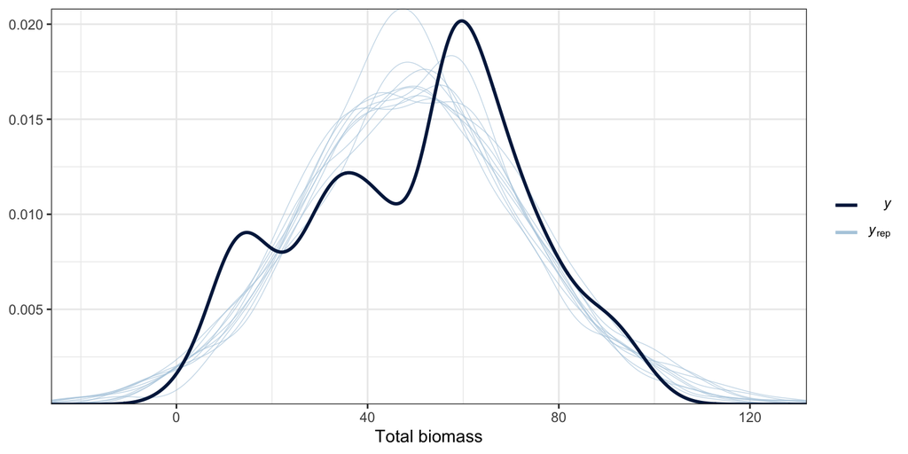

```r
brms::pp_check(PPA$mainEffect[[1]]) +
    labs(x = "Total biomass") +
    theme_bw()
```

The second PPC for the main effect is the average prediction (`y_rep`) for each real datapoint (`y`). A line indicates a 1:1 correspondence for reference.

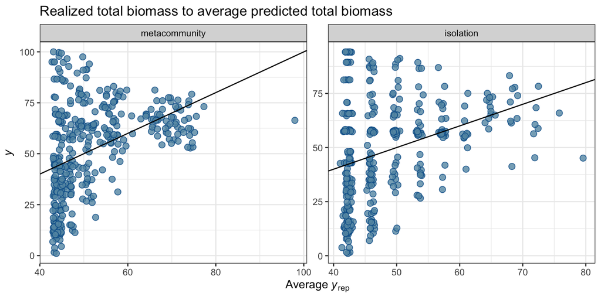

```r
brms::pp_check(PPA$mainEffect[[1]],
               type = 'scatter_avg_grouped',
               group = "Stage") +
    geom_abline(intercept = 0,
                slope = 1) +
    labs(title = "Realized total biomass to average predicted total biomass") +
    theme_bw()
```

Lastly, we inspect the highest-density interval (HDI) for each effect within the model. This characterizes the uncertainty of our posterior distributions. Highest-density intervals can be thought of as credibility intervals. A nice graphic explaining them can be found [here](https://mathematica.stackexchange.com/questions/173282/computing-credible-region-highest-posterior-density-from-empirical-distributio). I use the 89% HDI as recommended by Kruschke (2014), see [here](https://easystats.github.io/bayestestR/reference/hdi.html).

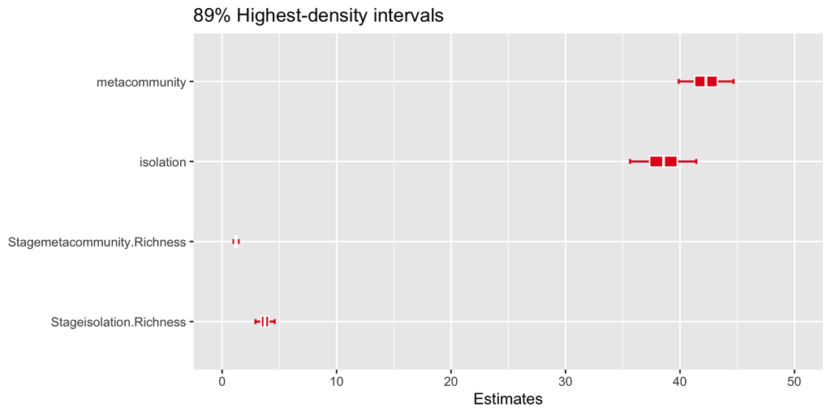

```r
sjPlot::plot_model(PPA$mainEffect[[1]],
                   title = "89% Highest-density intervals")
```

## 2.2 Treatment effects

For the treatment effect we incorporate the different richness treatments into the model, giving each combination a different intercept and slope.

We use the formula:

```r
brm(formula = total.biomass ~ -1 + Ninitial:Stage + Ninitial:Stage:Richness,
    data = PPA)
```

Note that both `Ninitial` and `Stage` are treated as categorical variables. Further, because both the monocultures and the singleton 64-species community have no variation with respect to realized diversity, they are omitted from this model.

The summary table:

```r
PPA$treatmentEffect[[1]]
```

```
##  Family: gaussian
##   Links: mu = identity; sigma = identity
## Formula: total.biomass ~ -1 + Ninitial:Stage + Ninitial:Stage:Richness
##    Data: d_ (Number of observations: 640)
## Samples: 4 chains, each with iter = 2000; warmup = 1000; thin = 1;
##          total post-warmup samples = 4000
##
## Population-Level Effects:
##                                        Estimate Est.Error l-95% CI u-95% CI Rhat Bulk_ESS Tail_ESS
## Ninitial2:Stagemetacommunity              73.50      9.07    55.82    91.28 1.00     5629     2934
## Ninitial4:Stagemetacommunity              99.52      8.40    82.63   116.02 1.00     5100     2724
## Ninitial8:Stagemetacommunity              97.70     12.79    72.29   122.34 1.00     5395     2724
## Ninitial16:Stagemetacommunity             66.78     13.72    39.70    93.33 1.00     5253     3005
## Ninitial32:Stagemetacommunity             74.03     17.84    39.17   108.54 1.00     5273     3068
## Ninitial2:Stageisolation                  49.88      6.91    36.58    63.39 1.00     5351     2112
## Ninitial4:Stageisolation                  72.86      6.09    61.12    85.06 1.00     5624     3136
## Ninitial8:Stageisolation                  71.40      5.81    60.05    82.79 1.00     5124     3024
## Ninitial16:Stageisolation                 64.11      6.87    50.55    77.48 1.00     3880     2456
## Ninitial32:Stageisolation                 50.61      7.16    36.34    64.80 1.00     5276     2894
## Ninitial2:Stagemetacommunity:Richness    -20.23      5.05   -29.88   -10.46 1.00     5722     2902
## Ninitial4:Stagemetacommunity:Richness    -15.14      2.57   -20.14   -10.08 1.00     5046     2985
## Ninitial8:Stagemetacommunity:Richness     -6.09      2.00    -9.94    -2.09 1.00     5341     2684
## Ninitial16:Stagemetacommunity:Richness    -0.19      1.19    -2.51     2.17 1.00     5266     3086
## Ninitial32:Stagemetacommunity:Richness    -0.35      0.78    -1.85     1.15 1.00     5261     3252
## Ninitial2:Stageisolation:Richness        -10.98      5.24   -21.24    -0.67 1.00     5479     2337
## Ninitial4:Stageisolation:Richness        -14.76      3.38   -21.37    -8.16 1.00     5571     3161
## Ninitial8:Stageisolation:Richness         -5.92      2.16   -10.14    -1.66 1.00     5175     2755
## Ninitial16:Stageisolation:Richness        -0.80      1.69    -4.13     2.45 1.00     3917     2578
## Ninitial32:Stageisolation:Richness         1.77      1.13    -0.46     3.99 1.00     5170     2740
##
## Family Specific Parameters:
##       Estimate Est.Error l-95% CI u-95% CI Rhat Bulk_ESS Tail_ESS
## sigma    17.40      0.50    16.48    18.41 1.00     7037     2716
##
## Samples were drawn using sampling(NUTS). For each parameter, Bulk_ESS
## and Tail_ESS are effective sample size measures, and Rhat is the potential
## scale reduction factor on split chains (at convergence, Rhat = 1).
```

We now see that there is an intercept for each combination of `Ninitial` and `Stage`, and a slope that describes this this combination with reference to `Richness`.

> Note the `Rhat` summary column: variation from 1.0 indicates the the model did not converge.

The R-squared:

```r
rstantools::bayes_R2(PPA$treatmentEffect[[1]])
```

```
##     Estimate  Est.Error      Q2.5     Q97.5
## R2 0.3371206 0.02434708 0.2885062 0.3836548
```

### 2.2.1 Posterior predictive checks

As before, initially we compare the distribution of the real data (`y`, black line) to simulated distributions output from our model (`y_rep`, blue lines).

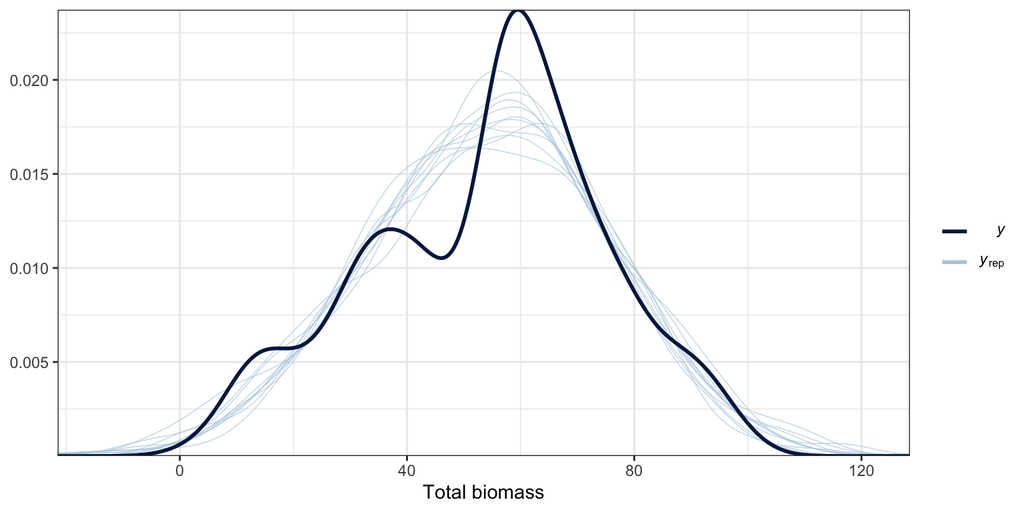

```r
brms::pp_check(PPA$treatmentEffect[[1]]) +
    labs(x = "Total biomass") +
    theme_bw()
```

And now a scatter plot of the simulated data in relation to the real data, grouping the comparison of `y` to `y_rep` by `Ninitial`.

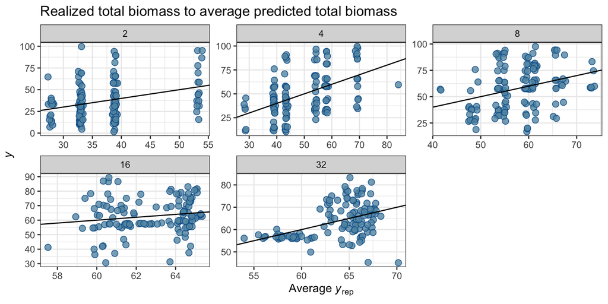

```r
brms::pp_check(PPA$treatmentEffect[[1]],
               type = 'scatter_avg_grouped',
               group = "Ninitial") +
    geom_abline(intercept = 0,
                slope = 1) +
    labs(title = "Realized total biomass to average predicted total biomass") +
    theme_bw()
```

The 89% highest-density interval (HDI):

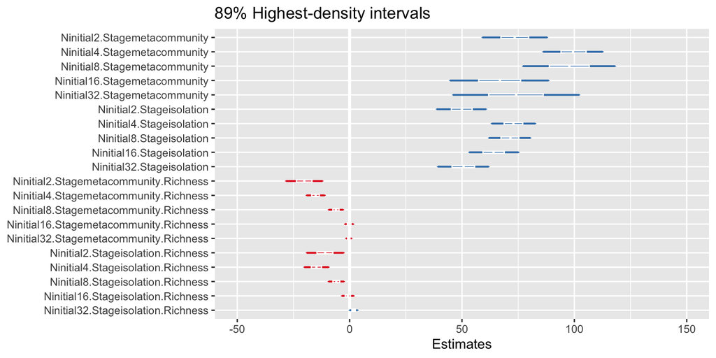

```r
sjPlot::plot_model(PPA$treatmentEffect[[1]],
                   title = "89% Highest-density intervals")
```

# 3 Plotting the final model fits

And now I plot the final fits:

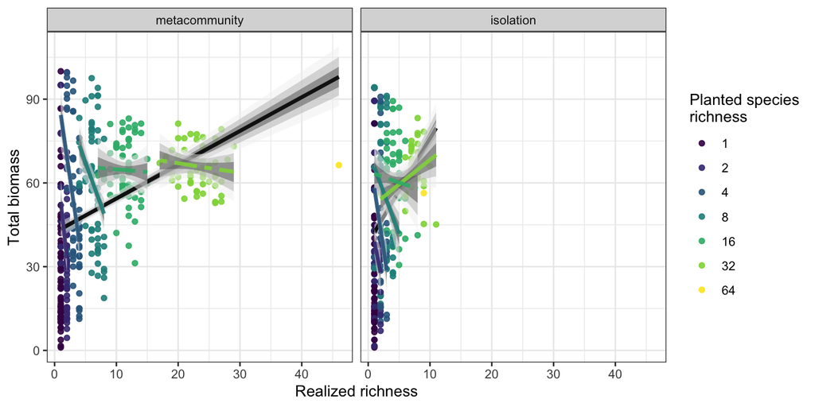

```r
extract_significances_mainEffect <- function(model_, measure_)
{
    hdi_ <- bayestestR::hdi(model_) %>%
        mutate(significant = !(0 >= CI_low & 0 <= CI_high))

    hdi_ <- hdi_ %>%
        filter(str_detect(Parameter, measure_)) %>%
        mutate(Stage = ifelse(str_detect(Parameter, "metacommunity"),
                              "metacommunity",
                              "isolation"))

    hdi_ <- hdi_ %>%
        mutate(Stage = as.factor(Stage)) %>%
        select(Stage, significant)

    hdi_ <- hdi_ %>%
        mutate(Stage = fct_relevel(Stage, c("metacommunity", "isolation")))

    return(hdi_)
}

extract_significances_treatmentEffect <- function(model_, measure_)
{
    hdi_ <- bayestestR::hdi(model_) %>%
        mutate(significant = !(0 >= CI_low & 0 <= CI_high))

    hdi_ <- hdi_ %>%
        filter(str_detect(Parameter, measure_)) %>%
        mutate(Stage = ifelse(str_detect(Parameter, "metacommunity"),
                              "metacommunity",
                              "isolation")) %>%
        mutate(Ninitial = str_extract(Parameter, "\\d+"))

    hdi_ <- hdi_ %>%
        mutate(Stage = as.factor(Stage),
               Ninitial = as.factor(Ninitial)) %>%
        select(Stage, Ninitial, significant)

    hdi_ <- hdi_ %>%
        mutate(Stage = fct_relevel(Stage, c("metacommunity", "isolation")))

    return(hdi_)
}

data <- PPA %>% unnest(data)
mainEffect_ <- PPA$mainEffect[[1]]
treatmentEffect_ <- PPA$treatmentEffect[[1]]

mainEffect <- data %>%
    group_by(Stage) %>%
    data_grid(Richness) %>%
    add_fitted_draws(mainEffect_) %>%
    inner_join(extract_significances_mainEffect(mainEffect_, "Richness"))

treatmentEffect <- data %>%
    filter(Ninitial %in% levels(treatmentEffect_$data$Ninitial)) %>%
    droplevels() %>%
    group_by(Ninitial, Stage) %>%
    data_grid(Richness) %>%
    add_fitted_draws(treatmentEffect_) %>%
    inner_join(extract_significances_treatmentEffect(treatmentEffect_, "Richness"))

ggplot() +
    geom_point(data = data,
               aes(x = Richness,
                   y = total.biomass,
                   color = Ninitial),
               alpha = 0.9) +
    stat_lineribbon(data = mainEffect,
                    aes(x = Richness,
                        y = .value,
                        group = Stage,
                        linetype = significant),
                    alpha = 0.5,
                    show.legend = FALSE) +
    stat_lineribbon(data = treatmentEffect,
                    aes(x = Richness,
                        y = .value,
                        color = Ninitial,
                        group = Ninitial,
                        linetype = significant),
                    alpha = 0.5,
                    show.legend = FALSE) +
    scale_linetype_manual(values = c("twodash", "solid")) +
    facet_grid(. ~ Stage) +
    labs(x = "Realized richness",
         y = "Total biomass",
         color = "Planted species\nrichness") +
    scale_color_viridis(discrete = TRUE) +
    scale_fill_brewer(palette = "Greys") +
    theme_bw()
```

Ribbons indicate 95%, 80%, and 50% credibility intervals. The black line represents the main effect, omitting the richness treatments. Dashed lines have estimates that include 0 within their 89% HDI.